# Comprehensive research on ensemble vs non-ensemble models

## Pima Indian Dataset

The Pima Indian Diabetes dataset is a well-known dataset in the field of medical research and machine learning. It contains medical records of Pima Indians, a population known for having high rates of diabetes. The dataset was collected by the National Institute of Diabetes and Digestive and Kidney Diseases and contains information on the health status and medical history of Pima Indians.

The dataset contains 768 instances, each representing a different patient. Each instance has 9 attributes, including the patient's number of pregnancies, glucose levels, blood pressure, skin thickness, insulin levels, body mass index (BMI), diabetes pedigree function, age, and whether the patient has diabetes or not. The last attribute, whether the patient has diabetes, is the target variable and is used to evaluate the performance of machine learning algorithms.

The Pima Indian Diabetes dataset has been widely used for research and has been analyzed using various statistical and machine learning techniques. The dataset is well suited for machine learning algorithms due to its moderate size and the presence of several attributes that are believed to be important for predicting the likelihood of diabetes. In addition, the dataset provides an opportunity to study the impact of various medical conditions on the onset of diabetes.

The Pima Indian Diabetes dataset has been used in many studies to develop predictive models for diabetes, including decision trees, random forests, support vector machines, and neural networks. The results of these studies have shown that machine learning algorithms can be used to predict diabetes with high accuracy, and that different algorithms can perform differently based on the specific characteristics of the dataset.

In conclusion, the Pima Indian Diabetes dataset is an important resource for researchers and practitioners interested in developing predictive models for diabetes. The dataset provides a rich source of information that can be used to gain insights into the relationship between various medical conditions and the onset of diabetes, and to develop effective algorithms for predicting the likelihood of diabetes.

```python
# Load the Pima Indians Diabetes dataset
url = "https://raw.githubusercontent.com/jbrownlee/Datasets/master/pima-indians-diabetes.data.csv"
df = pd.read_csv(url, header=None)
# Performing Exploratory Data Analysis
# Print the first few rows of the data
print("Sample of Dataset")
print("-----------------")
display(df.head())
```

```
Sample of Dataset
-----------------
```

|  | 0 | 1 | 2 | 3 | 4 | 5 | 6 | 7 | 8 |
| --- | --- | --- | --- | --- | --- | --- | --- | --- | --- |
| 0 | 6 | 148 | 72 | 35 | 0 | 33.6 | 0.627 | 50 | 1 |
| 1 | 1 | 85 | 66 | 29 | 0 | 26.6 | 0.351 | 31 | 0 |
| 2 | 8 | 183 | 64 | 0 | 0 | 23.3 | 0.672 | 32 | 1 |
| 3 | 1 | 89 | 66 | 23 | 94 | 28.1 | 0.167 | 21 | 0 |
| 4 | 0 | 137 | 40 | 35 | 168 | 43.1 | 2.288 | 33 | 1 |

```python
# Print the summary statistics of the numerical features
df.describe()
```

[output not shown]

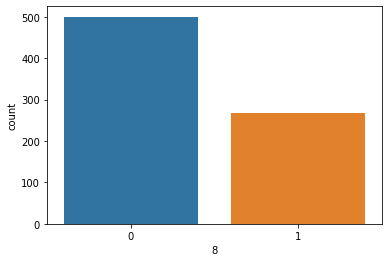

```python
# Plot the distribution of the target variable
sns.countplot(x=8, data=df)
plt.show()
```

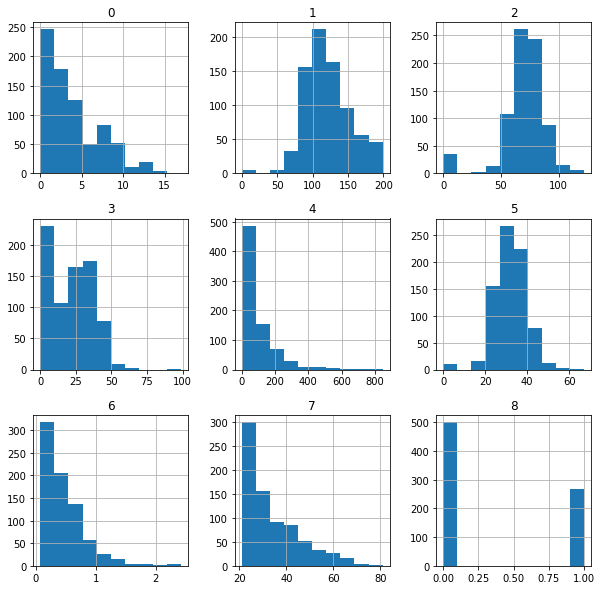

```python
# Plot histograms of the numerical features
df.hist(figsize=(10,10))
plt.show()
```

```python
# Split the data into features (X) and target (y)
X = df.iloc[:, :-1]
y = df.iloc[:, -1]
# Scale the input data
scaler = StandardScaler()
results = []
evaluate_models("Pima Indians Diabetes", X, y, scaler, results)
pima_results = pd.DataFrame(results, columns=['Dataset', 'Model', 'Accuracy Mean', 'Accuracy Std',
                                    'Precision Mean', 'Precision Std',
                                    'Recall Mean', 'Recall Std',
                                    'F1 Mean', 'F1 Std'])
display(pima_results)
```

|  | Dataset | Model | Accuracy Mean | Accuracy Std | Precision Mean | Precision Std | Recall Mean | Recall Std | F1 Mean | F1 Std |
| --- | --- | --- | --- | --- | --- | --- | --- | --- | --- | --- |
| 0 | Pima Indians Diabetes | Naive Bayes (Gaussian) | 0.751337 | 0.018602 | 0.662066 | 0.023871 | 0.585954 | 0.040379 | 0.621419 | 0.032039 |
| 1 | Pima Indians Diabetes | Naive Bayes (Bernoulli) | 0.717418 | 0.034662 | 0.601356 | 0.054851 | 0.570929 | 0.044057 | 0.585391 | 0.047054 |
| 2 | Pima Indians Diabetes | Decision Tree | 0.713675 | 0.048849 | 0.605427 | 0.087578 | 0.570790 | 0.057137 | 0.583383 | 0.051613 |
| 3 | Pima Indians Diabetes | Logistic Regression | 0.770885 | 0.024743 | 0.715469 | 0.045583 | 0.574703 | 0.052616 | 0.635804 | 0.041346 |
| 4 | Pima Indians Diabetes | Stochastic Gradient Descent | 0.673186 | 0.028760 | 0.532459 | 0.045998 | 0.641929 | 0.086707 | 0.576753 | 0.028990 |
| 5 | Pima Indians Diabetes | Support Vector Machine (SVC) | 0.770894 | 0.022488 | 0.724597 | 0.042874 | 0.559818 | 0.065463 | 0.628747 | 0.044688 |
| 6 | Pima Indians Diabetes | Support Vector Machine (LinearSVC) | 0.773491 | 0.024348 | 0.724650 | 0.046843 | 0.570999 | 0.051621 | 0.636993 | 0.040662 |
| 7 | Pima Indians Diabetes | K-Nearest Neighbors | 0.733113 | 0.020094 | 0.636062 | 0.034593 | 0.552341 | 0.039342 | 0.590578 | 0.032526 |
| 8 | Pima Indians Diabetes | Random Forest | 0.764400 | 0.033021 | 0.705084 | 0.062245 | 0.567365 | 0.055379 | 0.626750 | 0.048906 |
| 9 | Pima Indians Diabetes | AdaBoost | 0.763127 | 0.035368 | 0.694209 | 0.074043 | 0.593431 | 0.044589 | 0.637116 | 0.041323 |
| 10 | Pima Indians Diabetes | Gradient Boosting | 0.757873 | 0.035584 | 0.671296 | 0.052014 | 0.600978 | 0.077266 | 0.632345 | 0.061928 |

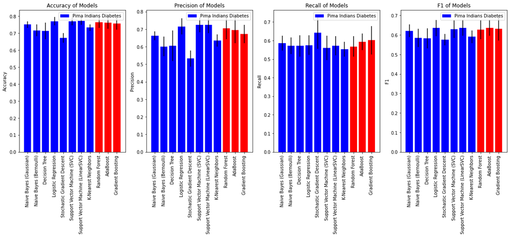

```python
visualise(pima_results)
```

## Titanic dataset

The Titanic dataset is a widely used dataset in machine learning and data analysis. It provides information on the passengers who were onboard the Titanic ship when it sank on April 15, 1912. The dataset includes various features such as passenger class, age, fare, name, and whether they survived or not. The goal of analyzing the Titanic dataset is to gain insights into the factors that may have contributed to the survival of the passengers. The Titanic dataset contains information on 887 passengers and crew members, including their demographic information, ticket information, and survival status. The data includes variables such as passenger class, sex, age, fare paid for the ticket, number of siblings and spouses on board, number of parents and children on board, and whether the passenger survived or not. The data is stored in a comma-separated value (CSV) file, which can be easily loaded into a pandas dataframe for analysis. The Titanic dataset is an excellent resource for data analysis, especially for beginners, as it provides a relatively small, yet complex dataset. The data is a mix of continuous, ordinal, and nominal data, making it a good test bed for various machine learning algorithms. One of the most common analysis tasks is to build a predictive model to determine the factors that influenced the survival of passengers and crew members. The dataset is usually split into two parts: training and testing data. The training data is used to build the model, while the testing data is used to evaluate the performance of the model. In conclusion, the Titanic dataset is a well-known and widely used dataset in machine learning and data analysis. It provides valuable insights into the factors that may have influenced the survival of passengers and crew members on the Titanic ship. The dataset is easy to access and provides a good opportunity for data analysts and machine learning practitioners to practice their skills and develop predictive models.

```python
df = pd.read_csv("https://web.stanford.edu/class/archive/cs/cs109/cs109.1166/stuff/titanic.csv")
# Performing Exploratory Data Analysis
print("Sample of Dataset")
print("-----------------")
display(df.head())
```

```
Sample of Dataset
-----------------
```

|  | Survived | Pclass | Name | Sex | Age | Siblings/Spouses Aboard | Parents/Children Aboard | Fare |
| --- | --- | --- | --- | --- | --- | --- | --- | --- |
| 0 | 0 | 3 | Mr. Owen Harris Braund | male | 22.0 | 1 | 0 | 7.2500 |
| 1 | 1 | 1 | Mrs. John Bradley (Florence Briggs Thayer) Cum... | female | 38.0 | 1 | 0 | 71.2833 |
| 2 | 1 | 3 | Miss. Laina Heikkinen | female | 26.0 | 0 | 0 | 7.9250 |
| 3 | 1 | 1 | Mrs. Jacques Heath (Lily May Peel) Futrelle | female | 35.0 | 1 | 0 | 53.1000 |
| 4 | 0 | 3 | Mr. William Henry Allen | male | 35.0 | 0 | 0 | 8.0500 |

```python
# Print the summary statistics of the numerical features
df.describe()
```

|  | Survived | Pclass | Age | Siblings/Spouses Aboard | Parents/Children Aboard | Fare |
| --- | --- | --- | --- | --- | --- | --- |
| count | 887.000000 | 887.000000 | 887.000000 | 887.000000 | 887.000000 | 887.00000 |
| mean | 0.385569 | 2.305524 | 29.471443 | 0.525366 | 0.383315 | 32.30542 |
| std | 0.487004 | 0.836662 | 14.121908 | 1.104669 | 0.807466 | 49.78204 |
| min | 0.000000 | 1.000000 | 0.420000 | 0.000000 | 0.000000 | 0.00000 |
| 25% | 0.000000 | 2.000000 | 20.250000 | 0.000000 | 0.000000 | 7.92500 |
| 50% | 0.000000 | 3.000000 | 28.000000 | 0.000000 | 0.000000 | 14.45420 |
| 75% | 1.000000 | 3.000000 | 38.000000 | 1.000000 | 0.000000 | 31.13750 |
| max | 1.000000 | 3.000000 | 80.000000 | 8.000000 | 6.000000 | 512.32920 |

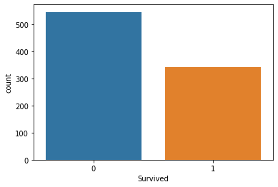

```python
# Plot the distribution of the target variable
sns.countplot(x='Survived', data=df)
plt.show()
```

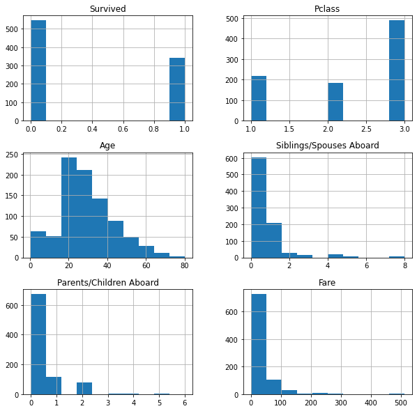

```python
# Plot histograms of the numerical features
df.hist(figsize=(10,10))
plt.show()
```

```python
df.drop(['Name'], axis=1, inplace=True)
X = df.drop("Survived", axis=1)
y = df["Survived"]
X = pd.get_dummies(X)
results = []
scaler = StandardScaler()
evaluate_models("Titanic", X, y, scaler, results)
titanic_results = pd.DataFrame(results, columns=['Dataset', 'Model', 'Accuracy Mean', 'Accuracy Std',
                                    'Precision Mean', 'Precision Std',
                                    'Recall Mean', 'Recall Std',
                                    'F1 Mean', 'F1 Std'])
display(titanic_results)
```

|  | Dataset | Model | Accuracy Mean | Accuracy Std | Precision Mean | Precision Std | Recall Mean | Recall Std | F1 Mean | F1 Std |
| --- | --- | --- | --- | --- | --- | --- | --- | --- | --- | --- |
| 0 | Titanic | Naive Bayes (Gaussian) | 0.791430 | 0.021690 | 0.742915 | 0.036079 | 0.704561 | 0.041675 | 0.722351 | 0.030162 |
| 1 | Titanic | Naive Bayes (Bernoulli) | 0.785755 | 0.019306 | 0.736936 | 0.014067 | 0.689685 | 0.062048 | 0.711378 | 0.038023 |
| 2 | Titanic | Decision Tree | 0.780213 | 0.034681 | 0.715445 | 0.047833 | 0.716752 | 0.063908 | 0.714887 | 0.047499 |
| 3 | Titanic | Logistic Regression | 0.792566 | 0.011372 | 0.752464 | 0.030564 | 0.692967 | 0.038281 | 0.720083 | 0.015928 |
| 4 | Titanic | Stochastic Gradient Descent | 0.763340 | 0.054667 | 0.722450 | 0.061194 | 0.614663 | 0.129520 | 0.660320 | 0.104383 |
| 5 | Titanic | Support Vector Machine (SVC) | 0.829753 | 0.020079 | 0.817923 | 0.021025 | 0.719139 | 0.060363 | 0.763811 | 0.036191 |
| 6 | Titanic | Support Vector Machine (LinearSVC) | 0.793677 | 0.018863 | 0.758971 | 0.036735 | 0.684058 | 0.035476 | 0.718696 | 0.026298 |
| 7 | Titanic | K-Nearest Neighbors | 0.812950 | 0.036758 | 0.772200 | 0.061624 | 0.737042 | 0.047933 | 0.752878 | 0.044220 |
| 8 | Titanic | Random Forest | 0.817425 | 0.029554 | 0.773724 | 0.022405 | 0.743009 | 0.076724 | 0.756601 | 0.047102 |
| 9 | Titanic | AdaBoost | 0.810646 | 0.025457 | 0.767337 | 0.056051 | 0.739770 | 0.028419 | 0.751506 | 0.023762 |
| 10 | Titanic | Gradient Boosting | 0.825303 | 0.018717 | 0.795123 | 0.035979 | 0.739898 | 0.039983 | 0.765431 | 0.024701 |

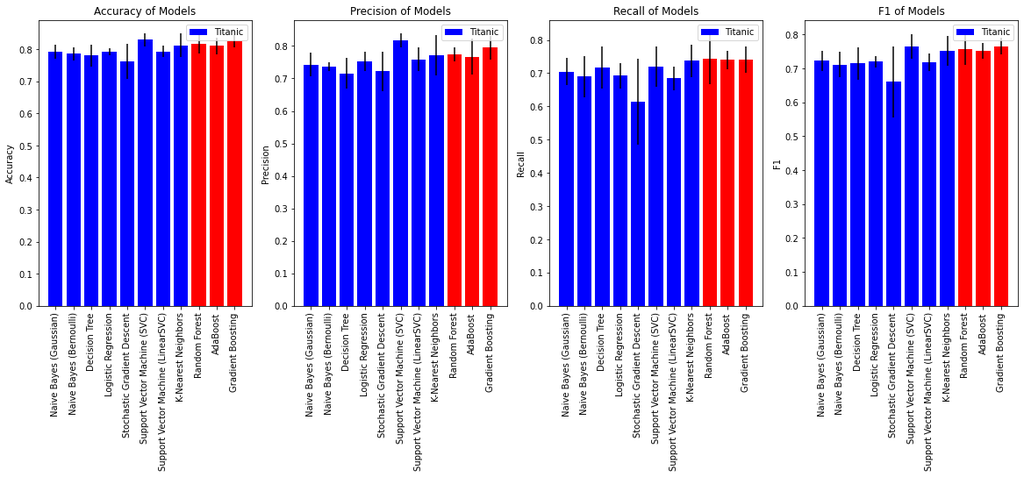

```python
visualise(titanic_results)
```

## Bank marketing Dataset

The "bank marketing" dataset is a commonly used dataset for the purpose of classification and prediction tasks in machine learning. It is used to determine whether a customer will subscribe to a bank term deposit or not. The dataset is based on a real-world direct marketing campaign run by a Portuguese banking institution, where the goal was to increase its deposit base by telemarketing existing customers. The data was collected between May 2008 and November 2010 and contains 45211 observations and 17 variables.

```python
# Load the dataset
url = "https://archive.ics.uci.edu/ml/machine-learning-databases/00222/bank.zip"
r= requests.get(url)
# zip_file = ZipFile(url)
z = ZipFile(io.BytesIO(r.content))
df = pd.read_csv(z.open("bank-full.csv"), sep=';')
df = df.drop("contact", axis=1)
```

```python
# Performing Exploratory Data Analysis
print("Sample of Dataset")
print("-----------------")
display(df.head())
```

```
Sample of Dataset
-----------------
```

|  | age | job | marital | education | default | balance | housing | loan | day | month | duration | campaign | pdays | previous | poutcome | y |
| --- | --- | --- | --- | --- | --- | --- | --- | --- | --- | --- | --- | --- | --- | --- | --- | --- |
| 0 | 58 | management | married | tertiary | no | 2143 | yes | no | 5 | may | 261 | 1 | -1 | 0 | unknown | no |
| 1 | 44 | technician | single | secondary | no | 29 | yes | no | 5 | may | 151 | 1 | -1 | 0 | unknown | no |
| 2 | 33 | entrepreneur | married | secondary | no | 2 | yes | yes | 5 | may | 76 | 1 | -1 | 0 | unknown | no |
| 3 | 47 | blue-collar | married | unknown | no | 1506 | yes | no | 5 | may | 92 | 1 | -1 | 0 | unknown | no |
| 4 | 33 | unknown | single | unknown | no | 1 | no | no | 5 | may | 198 | 1 | -1 | 0 | unknown | no |

```python
# Print the summary statistics of the numerical features
df.describe()
```

|  | age | balance | day | duration | campaign | pdays | previous |
| --- | --- | --- | --- | --- | --- | --- | --- |
| count | 45211.000000 | 45211.000000 | 45211.000000 | 45211.000000 | 45211.000000 | 45211.000000 | 45211.000000 |
| mean | 40.936210 | 1362.272058 | 15.806419 | 258.163080 | 2.763841 | 40.197828 | 0.580323 |
| std | 10.618762 | 3044.765829 | 8.322476 | 257.527812 | 3.098021 | 100.128746 | 2.303441 |
| min | 18.000000 | -8019.000000 | 1.000000 | 0.000000 | 1.000000 | -1.000000 | 0.000000 |
| 25% | 33.000000 | 72.000000 | 8.000000 | 103.000000 | 1.000000 | -1.000000 | 0.000000 |
| 50% | 39.000000 | 448.000000 | 16.000000 | 180.000000 | 2.000000 | -1.000000 | 0.000000 |
| 75% | 48.000000 | 1428.000000 | 21.000000 | 319.000000 | 3.000000 | -1.000000 | 0.000000 |
| max | 95.000000 | 102127.000000 | 31.000000 | 4918.000000 | 63.000000 | 871.000000 | 275.000000 |

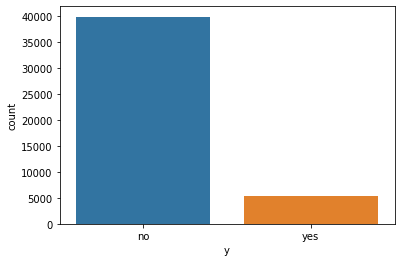

```python
# Plot the distribution of the target variable
sns.countplot(x='y', data=df)
plt.show()
```

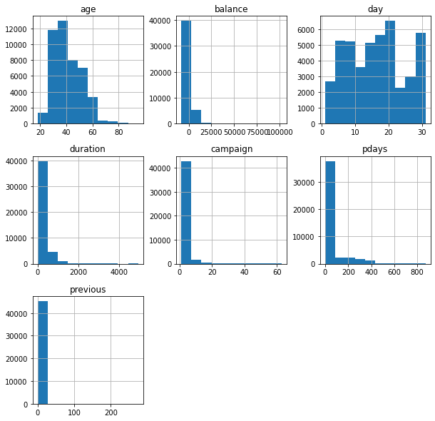

```python
# Plot histograms of the numerical features
df.hist(figsize=(10,10))
plt.show()
```

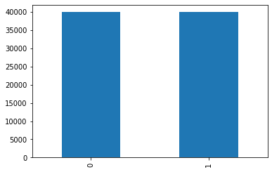

```python
# Here based on previous histogram plot we can observe dataset is high imbalance. Hence we are trying to balance it using SMOTE method
# Split the data into training and testing sets
X = df.iloc[:, :-1]
y = df.iloc[:, -1]
y = df['y'].map({'yes': 1, 'no': 0})
X = pd.get_dummies(X)

smote = SMOTE(random_state=0)
X, y = smote.fit_resample(X, y)
y.value_counts().plot(kind='bar')
# sns.countplot(x=0, data=y)
# plt.show()
```

```python
# X = df.iloc[:, :-1]
# y = df.iloc[:, -1]
# y = df['y'].map({'yes': 1, 'no': 0})
# X = pd.get_dummies(X)
# Preview the first 5 rows of the data
results = []
scaler = StandardScaler()
evaluate_models("Bank_dataset", X, y, scaler, results)
bank_dataset = pd.DataFrame(results, columns=['Dataset', 'Model', 'Accuracy Mean', 'Accuracy Std',
                                    'Precision Mean', 'Precision Std',
                                    'Recall Mean', 'Recall Std',
                                    'F1 Mean', 'F1 Std'])
display(bank_dataset)
```

|  | Dataset | Model | Accuracy Mean | Accuracy Std | Precision Mean | Precision Std | Recall Mean | Recall Std | F1 Mean | F1 Std |
| --- | --- | --- | --- | --- | --- | --- | --- | --- | --- | --- |
| 0 | Bank_dataset | Naive Bayes (Gaussian) | 0.716385 | 0.110302 | 0.680826 | 0.097920 | 0.816460 | 0.211808 | 0.731067 | 0.136506 |
| 1 | Bank_dataset | Naive Bayes (Bernoulli) | 0.790641 | 0.077103 | 0.802498 | 0.128754 | 0.841962 | 0.205330 | 0.789090 | 0.107230 |
| 2 | Bank_dataset | Decision Tree | 0.775575 | 0.050736 | 0.751270 | 0.096967 | 0.891559 | 0.198664 | 0.788798 | 0.078524 |
| 3 | Bank_dataset | Logistic Regression | 0.859489 | 0.116971 | 0.885547 | 0.106146 | 0.866032 | 0.263803 | 0.836351 | 0.174134 |
| 4 | Bank_dataset | Stochastic Gradient Descent | 0.837346 | 0.137735 | 0.866581 | 0.139674 | 0.866633 | 0.263102 | 0.822917 | 0.176313 |
| 5 | Bank_dataset | Support Vector Machine (SVC) | 0.794436 | 0.104462 | 0.805608 | 0.135226 | 0.865707 | 0.263578 | 0.786534 | 0.153069 |
| 6 | Bank_dataset | Support Vector Machine (LinearSVC) | 0.857711 | 0.125589 | 0.887978 | 0.119864 | 0.865631 | 0.264417 | 0.836134 | 0.178291 |
| 7 | Bank_dataset | K-Nearest Neighbors | 0.775587 | 0.069556 | 0.767941 | 0.121279 | 0.879234 | 0.232016 | 0.781308 | 0.107938 |
| 8 | Bank_dataset | Random Forest | 0.804506 | 0.085875 | 0.803548 | 0.119799 | 0.879484 | 0.238903 | 0.801359 | 0.125392 |
| 9 | Bank_dataset | AdaBoost | 0.844121 | 0.092074 | 0.856062 | 0.100008 | 0.870141 | 0.239432 | 0.828884 | 0.140508 |
| 10 | Bank_dataset | Gradient Boosting | 0.793498 | 0.073506 | 0.784920 | 0.101350 | 0.873197 | 0.229936 | 0.792551 | 0.114420 |

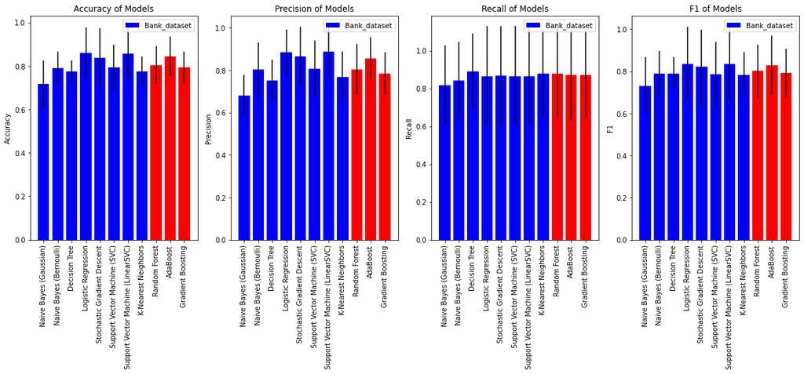

```python
visualise(bank_dataset)
```